# Shark Tank Analysis

Vee Kalkunte

March 22, 2020

## Welcome to the tank!

Shark Tank is a reality TV hit that premiered on August of 2009, and has now entered 2020 with its 11th season. The premise is straightforward: an entrepeneur comes into the tank and pitches their company to 5 “sharks” (investors) in order to recieve a cash investment/mentorship/help in return for a stake in their company. The most common investors, and the ones we’ll be focusing on, are Mark Cuban, Lori Greiner, Robert Herjavec, Daymond John, Barbara Corcoran, and Kevin O’Leary. There have been guest sharks over the seasons, but as they’re in a minority, this analysis will focus on the big 6.

### What are we investigating?

We’re looking at a Shark Tank dataset by @halletecco, which presents to us data from the first 6 seasons of the show. Using readr toimport our data, dyplr to clean our data, and ggplot2 to display graphs.

Here’s a quick look at the dataset:

```
## # A tibble: 6 x 21
##     Row Season `No. in series` Company Deal  Industry `Entrepreneur G~ Amount
##   <dbl>  <dbl>           <dbl> <chr>   <chr> <chr>    <chr>            <chr>
## 1    NA     NA              NA <NA>    <NA>  <NA>     <NA>             <NA>
## 2     2      1               1 Ava th~ Yes   Healthc~ Female           $50,0~
## 3     3      1               1 Mr. To~ Yes   Food an~ Male             $460,~
## 4     4      1               1 Wispots No    Busines~ Male             <NA>
## 5     5      1               1 Colleg~ No    Lifesty~ Male             <NA>
## 6     6      1               1 Ionic ~ No    Uncerta~ Male             <NA>
## # ... with 13 more variables: Equity <chr>, Valuation <chr>, Corcoran <dbl>,
## #   Cuban <dbl>, Greiner <dbl>, Herjavec <dbl>, John <dbl>, `O'Leary` <dbl>,
## #   Harrington <dbl>, Guest <dbl>, `# Sharks` <dbl>, `$ per shark` <chr>,
## #   `Details / Notes` <chr>
```

As we can see, there’s a little bit of cleaning we need to do before we’re ready to use this dataset. In particular, we’re going to need to figure out how to get rid of the NAs, as well as how to mutate the deal data such that we have columns we can actually make tables/graphs out of.

### Quick Cleaning Montage

An overview of what we’ve done to clean up the data:

```r
#first rename the variables so they're more comprehensible
names(shark) <- c("Row", "Season", "Number", "Company", "Deal", "Industry", "Gender", "Amount", "Equity", "Valuation", "Corcoran", "Cuban", "Greiner", "Herjavec", "John", "OLeary", "Harrington", "Guest", "numSharks", "perShark", "Details")

#Turn deals, and deals with specific sharks, to logicals rather than characters
one <- shark %>%
  mutate(DealBool = ifelse(Deal == "Yes", TRUE, FALSE)) %>%
  mutate(CorcoranDeal = ifelse(is.na(Corcoran), FALSE, TRUE)) %>%
  mutate(CubannDeal = ifelse(is.na(Cuban), FALSE, TRUE)) %>%
  mutate(GrenierDeal = ifelse(is.na(Greiner), FALSE, TRUE)) %>%
  mutate(HerjavecDeal = ifelse(is.na(Herjavec), FALSE, TRUE)) %>%
  mutate(JohnDeal = ifelse(is.na(John), FALSE, TRUE)) %>%
  mutate(OLearyDeal = ifelse(is.na(OLeary), FALSE, TRUE)) %>%
  mutate(HarringtonDeal = ifelse(is.na(Harrington), FALSE, TRUE)) %>%
  mutate(GuestDeal = ifelse(is.na(Guest), FALSE, TRUE))

#Turn seasons, gender, and Industry into factors
two <- one %>% mutate(sex = as.factor(Gender)) %>%
  mutate(seasons = as.factor(Season)) %>%
  mutate(Industries = as.factor(Industry))

#Turn valuation, amount, perShark, and equity into numericals
three <- two %>%
  mutate(amount = parse_number(Amount)) %>%
  mutate(valuation = parse_number(Valuation)) %>%
  mutate(percent = parse_number(Equity)) %>%
  mutate(eachShark = parse_number(perShark)) %>%
  mutate(numShark = numSharks)

#pull out our new variables (rather than the old ones) and get rid of that extra blank row
data <- three[, c(1, 32, 3, 4, 22, 33, 31, 34, 36, 35, 23, 24, 25, 26, 27, 28, 29, 30, 38, 37, 21)]
names(data) <- c("Row", "Season", "Number", "Company", "Deal", "Industry", "Gender", "Amount", "Equity", "Valuation", "Corcoran", "Cuban", "Greiner", "Herjavec", "John", "OLeary", "Harrington", "Guest", "numSharks", "perShark", "Details")
data <- data %>% filter(!is.na(Season)) %>% mutate(Row = Row-1)

#Let's also break it down by whether or not someone got a deal, and with who.
barbaraDeals <- data %>% filter(Corcoran)
markDeals <- data %>% filter(Cuban)
loriDeals <- data %>% filter(Greiner)
robertDeals <- data %>% filter(Herjavec)
daymondDeals <- data %>% filter(John)
kevinDeals <- data %>% filter(OLeary)
multiSharkDeals <- data %>% filter(numSharks > 1)

deal <- data %>% filter(!is.na(Amount))
noDeal <- data %>% filter(is.na(Amount))
```

Here’s a look at our cleaned up dataset:

```
## # A tibble: 6 x 21
##     Row Season Number Company Deal  Industry Gender Amount Equity Valuation
##   <dbl> <fct>   <dbl> <chr>   <lgl> <fct>    <fct>   <dbl>  <dbl>     <dbl>
## 1     1 1           1 Ava th~ TRUE  Healthc~ Female  50000     55     90909
## 2     2 1           1 Mr. To~ TRUE  Food an~ Male   460000     50    920000
## 3     3 1           1 Wispots FALSE Busines~ Male       NA     NA        NA
## 4     4 1           1 Colleg~ FALSE Lifesty~ Male       NA     NA        NA
## 5     5 1           1 Ionic ~ FALSE Uncerta~ Male       NA     NA        NA
## 6     6 1           2 A Perf~ TRUE  Food an~ Female 500000     50   1000000
## # ... with 11 more variables: Corcoran <lgl>, Cuban <lgl>, Greiner <lgl>,
## #   Herjavec <lgl>, John <lgl>, OLeary <lgl>, Harrington <lgl>, Guest <lgl>,
## #   numSharks <dbl>, perShark <dbl>, Details <chr>
```

We still have some NAs floating around there, but we can filter them out as needed - if we took them all out right now, it would impact our analysis in a detrimental way - there’s a lot of observations with partially missing data, so they can still be useful. Besides - Amount, Equity, and Valuation only record the *closing* amount, equity, and valuation. Becuase of this, getting rid of rows with NAs would limit us to the deals only dataset, and then some.

## General Trends

### Distribution of Deals by Gender:

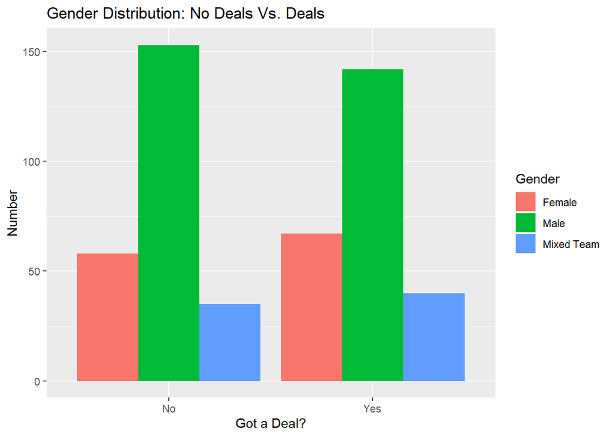

As we can see, the distribution of gender between the group that got a deal and the group that didn’t get a deal isn’t too different - there’s just a bit more women on the group that did get the deal.

# Distribution of deals by Industry:

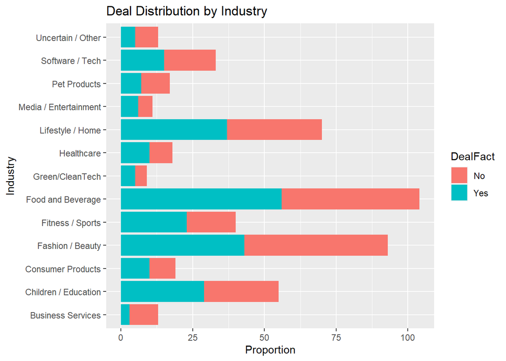

Some observations, as there are differneces in the success rate betweeen industries:

- The most common industry an entrepeneur is in is Food, with Fasion following.
- The least common is Green, Business services, and Media companies.
- Fitness companies have the highest proportion of deals.
- Business services and pet products have the least amount of success.

### Distributions of Deal Amount, Equity Taken, Valuation Given:

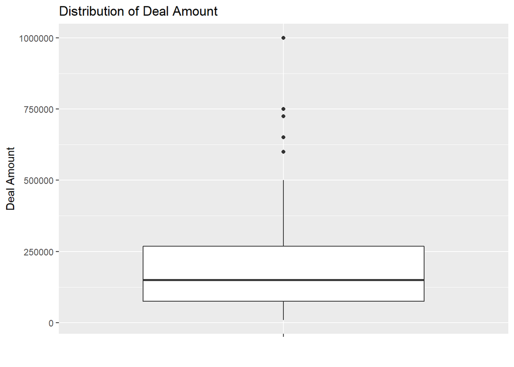

[output not shown]

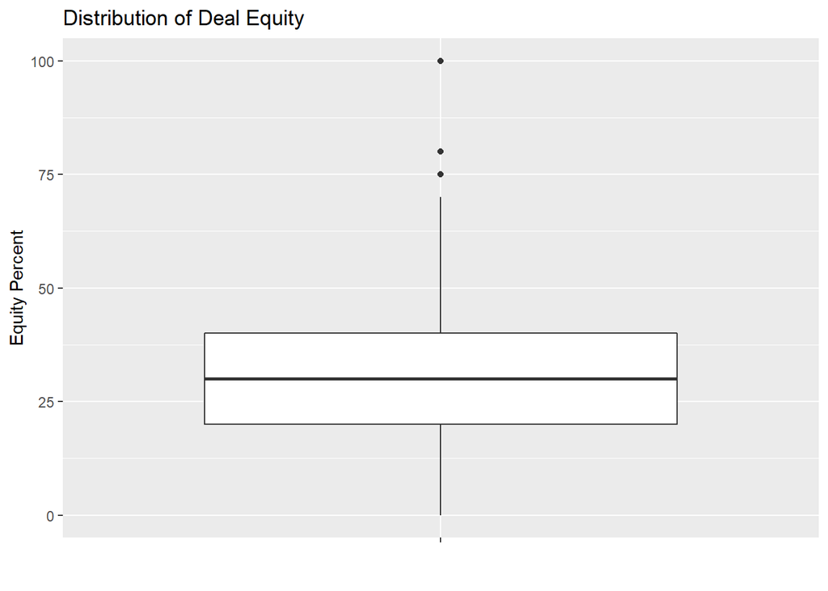

```
## # A tibble: 1 x 4
##   `Min Equity` `Median Equity` `Mean Equity` `Max Equity`
##   <formttbl>   <formttbl>      <formttbl>    <formttbl>
## 1 0.00         30.00           31.63         100.00
```

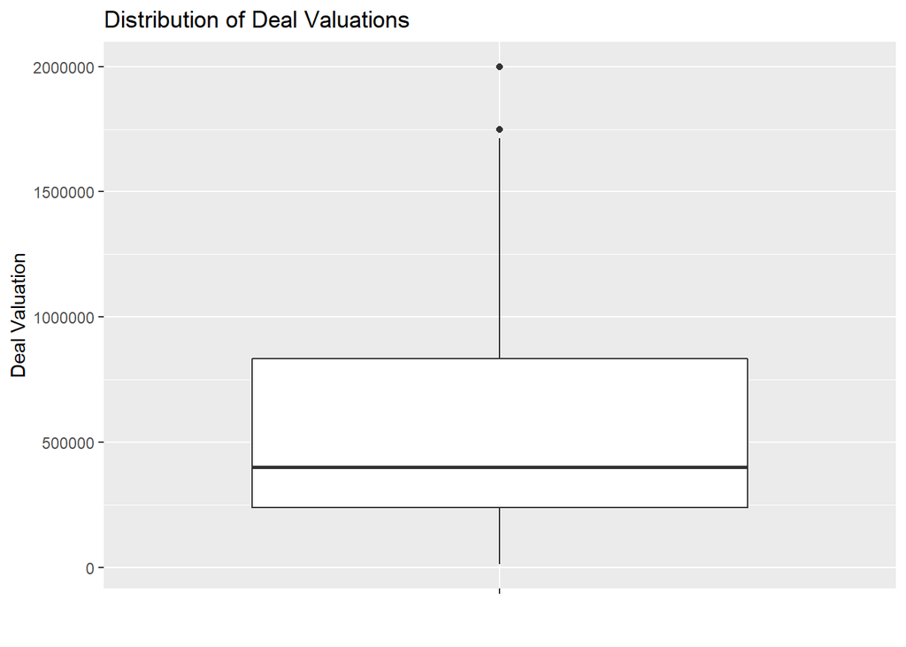

[output not shown]

But this is an overall perspective - intuitively, we can guess that these metrics will change across industry. To see just how much, and to see what industries take the cake in each catagory, let’s break it down:

```
##                 Industry  Mean Amount Mean Equity Mean Ending Valuation
## 1      Business Services   225,000.00      33.33%            800,000.00
## 2   Children / Education   137,413.79      28.86%            851,671.86
## 3      Consumer Products   211,000.00      38.80%            718,747.90
## 4       Fashion / Beauty   206,860.47      34.41%            847,519.98
## 5       Fitness / Sports   305,869.57      30.91%          1,283,666.91
## 6      Food and Beverage   247,407.41      31.44%          1,419,848.41
## 7        Green/CleanTech 1,290,000.00      28.40%          3,263,445.40
## 8             Healthcare   538,000.00      33.60%          1,990,193.80
## 9       Lifestyle / Home   181,944.44      30.83%            982,870.42
## 10 Media / Entertainment   666,666.67      16.83%          5,377,976.17
## 11          Pet Products    96,428.57      35.71%            305,102.00
## 12       Software / Tech   193,769.23      25.85%          1,215,699.31
## 13     Uncertain / Other   505,000.00      52.40%          1,430,476.20
```

## Shark-Specific Trends

Now, let’s break the data down to observe some shark-specific trends:

### Barbara Corcoran

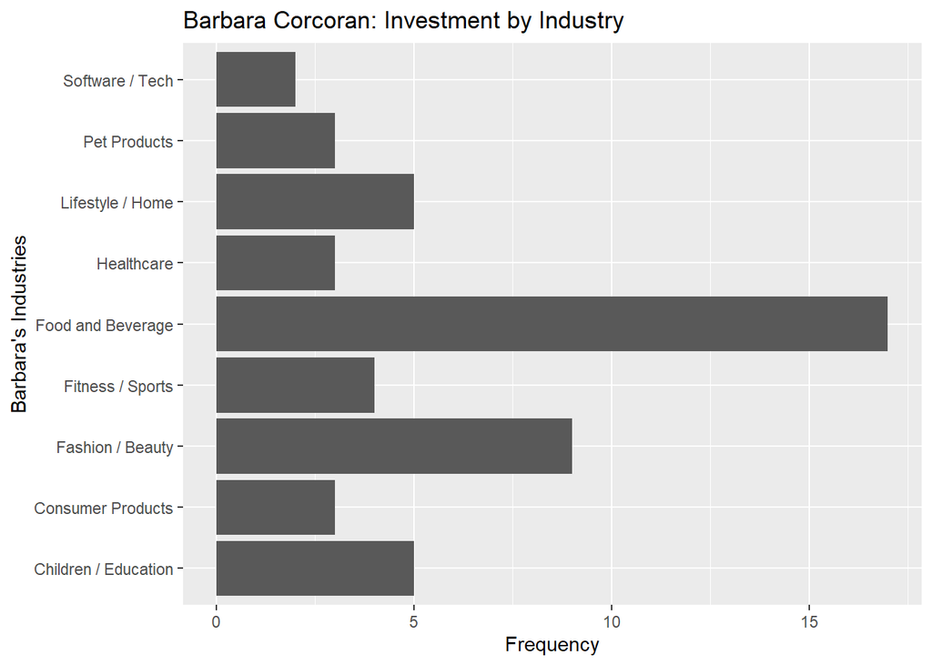

```
## # A tibble: 1 x 4
##   Companies `Mean Amount` `Mean Equity` `Mean Ending`
##       <int> <formttbl>    <formttbl>    <formttbl>
## 1        51 148,039.22    33.20%        582,263.76
```

### Lori Greiner

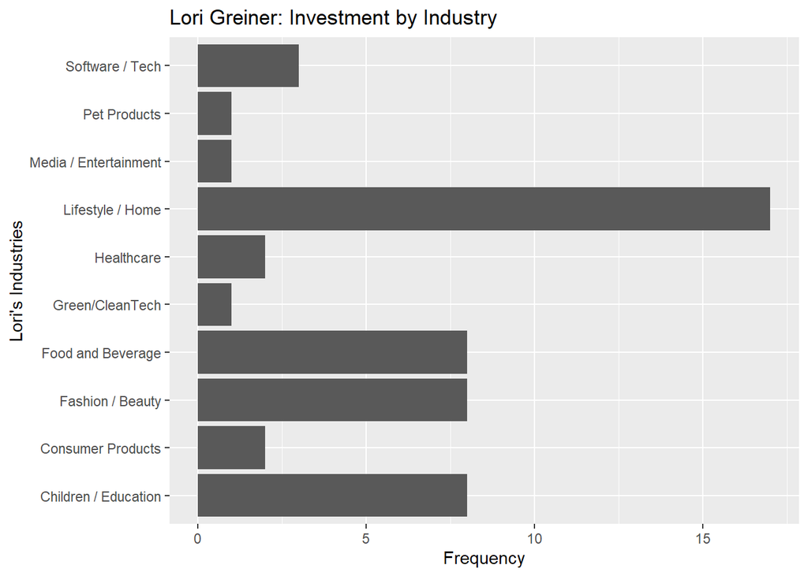

```
## # A tibble: 1 x 4
##   Companies `Mean Amount` `Mean Equity` `Mean Ending`
##       <int> <formttbl>    <formttbl>    <formttbl>
## 1        50 221,900.00    26.64%        1,287,909.24
```

### Mark Cuban

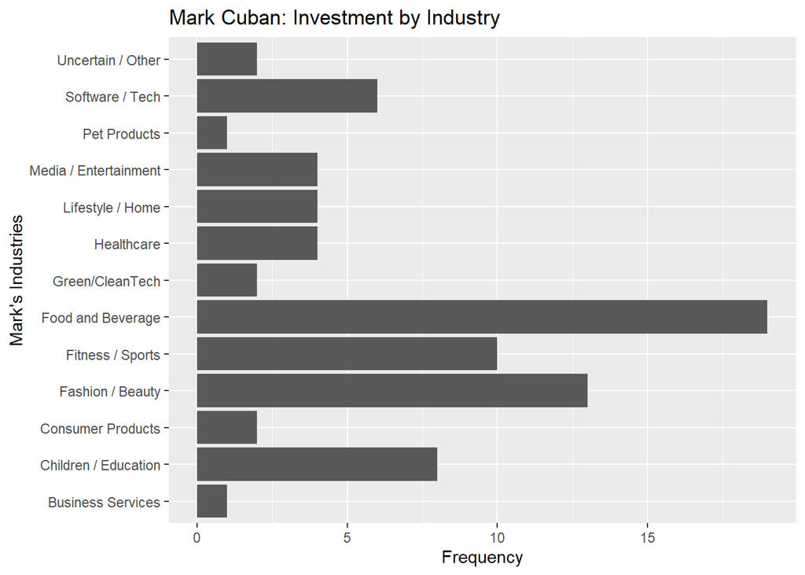

```
## # A tibble: 1 x 4
##   Companies `Mean Amount` `Mean Equity` `Mean Ending`
##       <int> <formttbl>    <formttbl>    <formttbl>
## 1        75 327,933.33    31.52%        1,672,496.27
```

### Daymond John

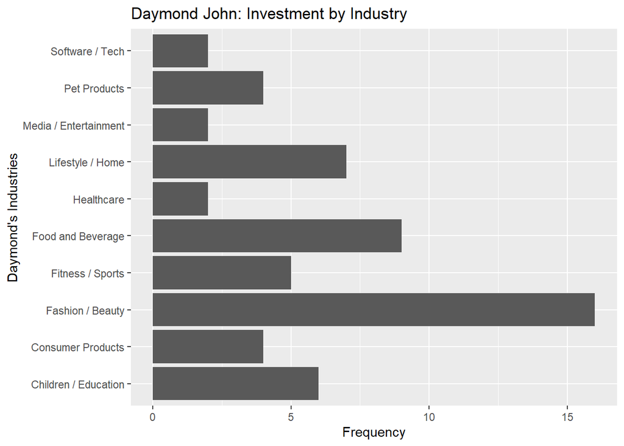

```
## # A tibble: 1 x 4
##   Companies `Mean Amount` `Mean Equity` `Mean Ending`
##       <int> <formttbl>    <formttbl>    <formttbl>
## 1        56 204,892.86    35.99%        891,447.36
```

### Robert Herjavec

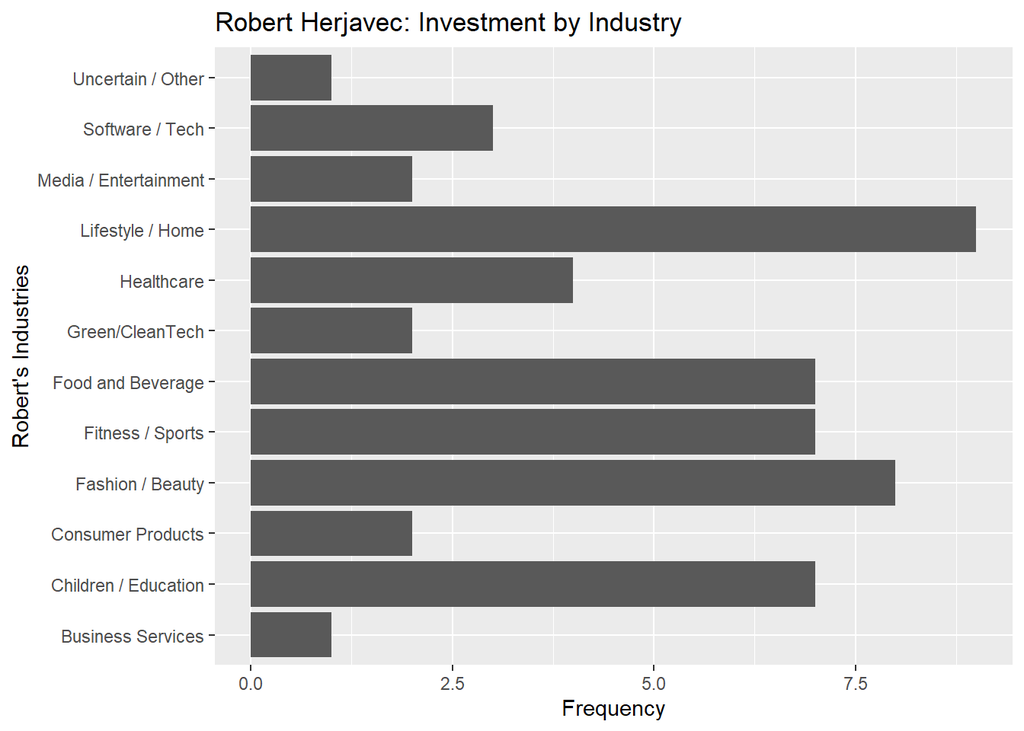

```
## # A tibble: 1 x 4
##   Companies `Mean Amount` `Mean Equity` `Mean Ending`
##       <int> <formttbl>    <formttbl>    <formttbl>
## 1        51 423,039.22    29.25%        1,718,024.35
```

### Mr. Wonderful

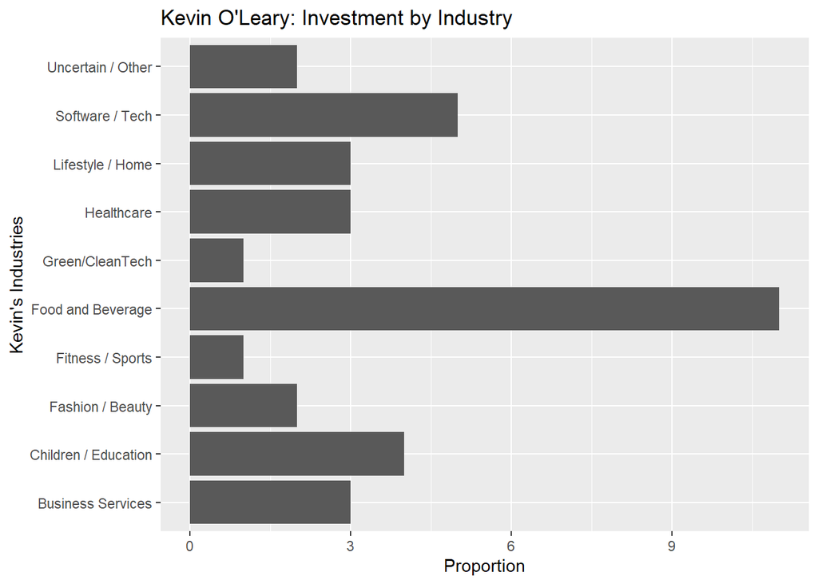

```
## # A tibble: 1 x 4
##   Companies `Mean Amount` `Mean Equity` `Mean Ending`
##       <int> <formttbl>    <formttbl>    <formttbl>
## 1        31 359,838.71    31.81%        1,836,229.97
```

Of course, we see the well-advertized specialities reflected in their frequency of investment within companies as well.

## Notes for Further Research

A few notes for further research:

- Of course, the more recent seasons
- Note that we didn’t have the asked equity and amounts, only the closed equity and amounts. This means that we can’t measure how much of a difference there is between ask and delivery, as well as the trends within the asks themselves. That omitted data may be pivotal for developing a model for predicting whether or not a company gets a deal.

### Sources

Dataset from Halle Tecco from Quora (https://www.quora.com/What-have-you-learned-from-watching-the-television-program-Shark-Tank/answer/Halle-Tecco) Produced in R Studio